# Reproducible Research: Peer Assessment 1

Pieter van der Want

10/10/2019

## Loading and preprocessing the data

Here we will load the data into R

```r
activity <- read.csv("activity.csv")
```

## What is mean total number of steps taken per day?

Calculate the total number of steps taken per day and print the histogram:

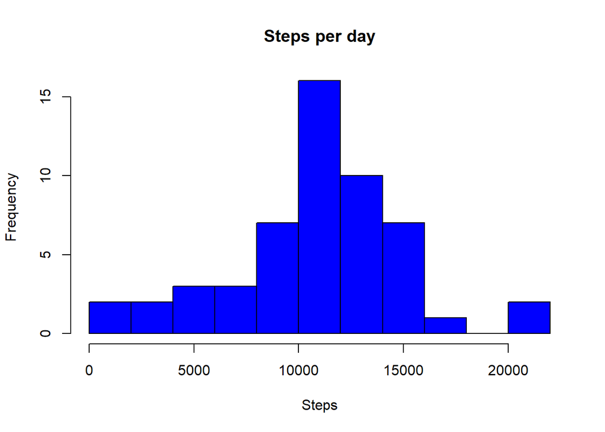

```r
totsteps <- aggregate(steps ~ date, activity, sum)
hist(totsteps$steps, main = "Steps per day", xlab = "Steps", col = "Blue", breaks = 8)
```

Calculate the mean and median of the total number of steps taken per day:

```r
meansteps <- mean(totsteps$steps)
medsteps <- median(totsteps$steps)
```

The mean is: 10766.19.  
The median is: 10765.

## What is the average daily activity pattern?

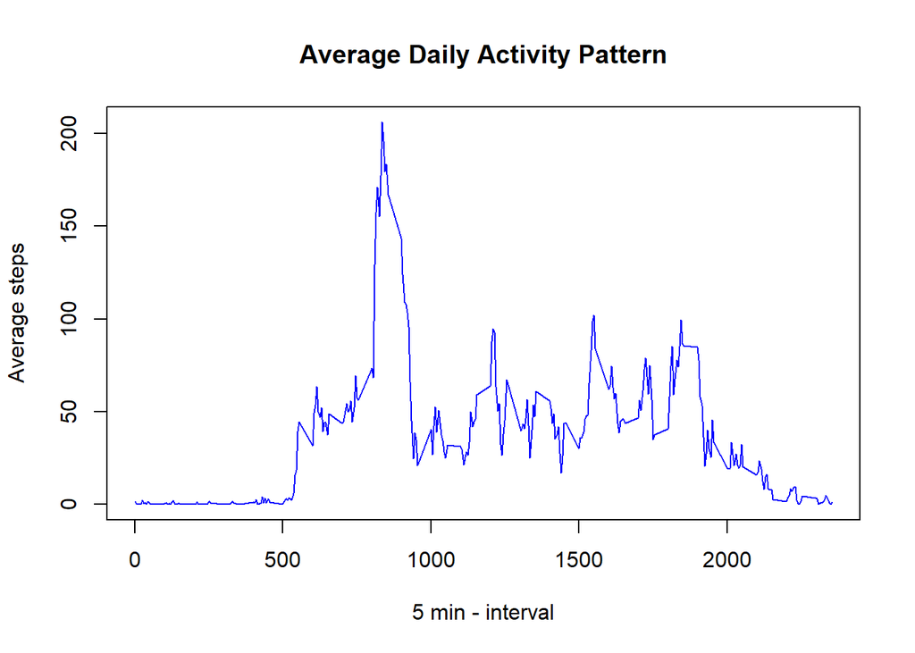

```r
stepsint <- aggregate(steps ~ interval, activity, mean)
plot(stepsint$interval, stepsint$steps, type="l", xlab = "5 min - interval",
     ylab = "Average steps", main = "Average Daily Activity Pattern", col = "Blue")
```

Now to calculate the interval that on average contains the maximum number of steps:

```r
maxint <- stepsint[which.max(stepsint$steps),]
```

Interval 835 contains on average the maximum number of steps.

## Imputing missing values

To create the missing values I will be using the mean interval steps already calculated and rounding them  
to replace the missing values.

```r
newactiv <- activity
nas <- which(is.na(activity$steps))      ## First find the na's
steps <- round(stepsint$steps)           ## round the steps
nas <- as.data.frame(nas)                ## Coerce the steps and the na positions
nas[,2] <- steps
colnames(nas) <- c("row","steps")
newactiv$steps[nas$row] <- nas$steps     ## Replace the na values for steps with rounded steps
```

Now to make a histogram of the new data

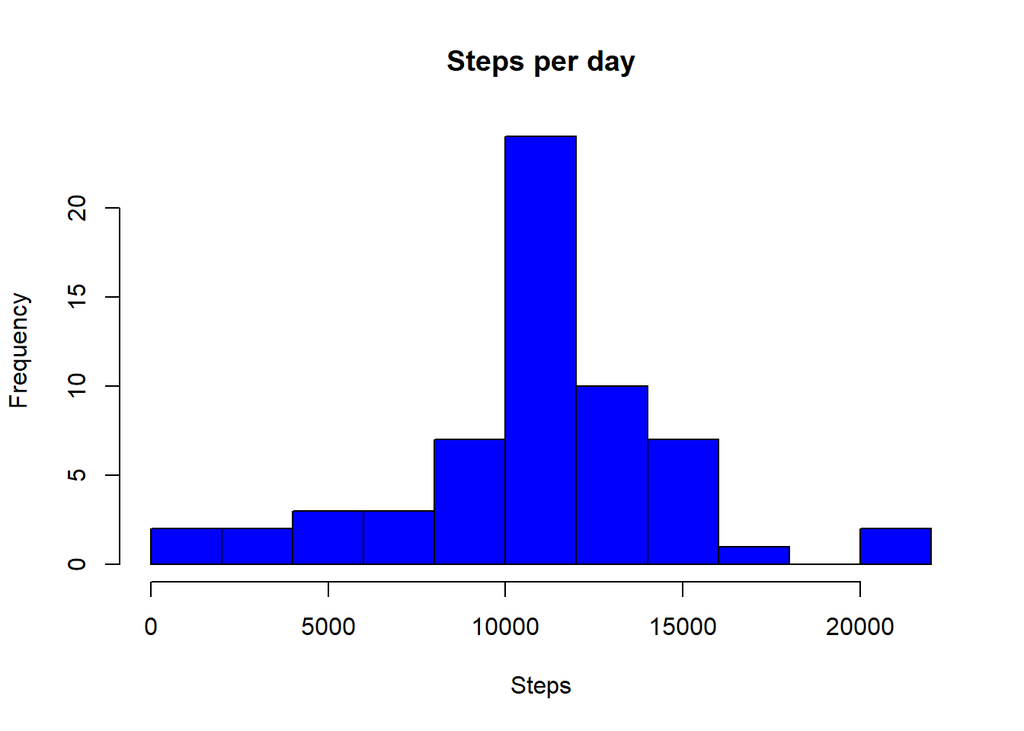

```r
totsteps <- aggregate(steps ~ date, newactiv, sum)
hist(totsteps$steps, main = "Steps per day", xlab = "Steps", col = "Blue", breaks = 8)
```

```r
meansteps <- mean(totsteps$steps)
medsteps <- median(totsteps$steps)
```

The mean is: 10765.64.  
The median is: 10762.

## Are there differences in activity patterns between weekdays and weekends?

Add a column “day” for the day type “weekend” and “weekday”

```r
newactiv$day <- as.POSIXlt(newactiv$date)$wday
newactiv$day <- as.factor(ifelse(newactiv$day == 0 | newactiv$day == 6, "weekend", "weekday"))
```

Seperate the day types

```r
weekday <- newactiv[newactiv$day == "weekday",]
weekend <- newactiv[newactiv$day == "weekend",]
stepsintweek <- aggregate(steps ~ interval, weekday, mean)
stepsintend <- aggregate(steps ~ interval, weekend, mean)
```

Create a plot to show the results

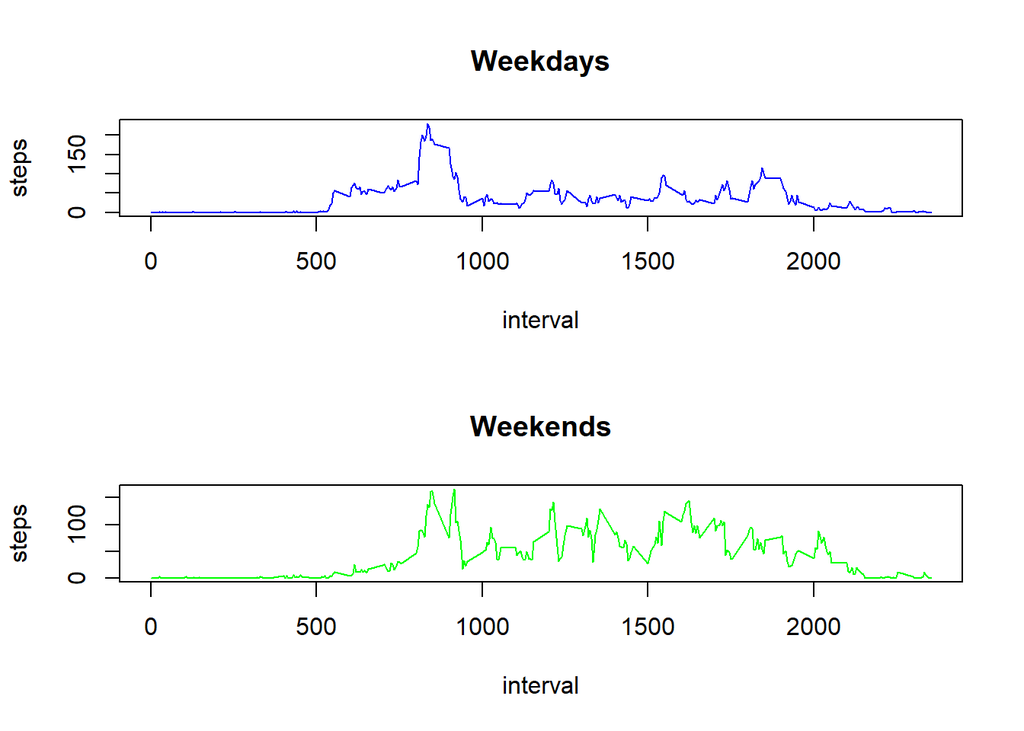

```r
par(mfrow = c(2, 1))

plot(stepsintweek, type = "l", col = "blue", main = "Weekdays")
plot(stepsintend, type = "l", col = "green", main = "Weekends")
```

From these plots we can see that there was an activity spike in the morning during weekdays, where as the  
weekends saw a normal activity patern throughout the day.